# Final Exam Time Series Fall 2019 (Take Home)

Javier Saldana

Due Saturday, December 7, 2019 at 11:59 pm Central Time

**In Unit 13 we looked at an RNN model of the monthly sunspot data from 1745 to 2013 (sunspot.month in base R). This model yielded an ASE of approximately 900 when forecasting a year in advance (12 months). Your goal here will be to compare an ARMA or ARIMA model to the RNN model.**

1. Stationarity: Here we will check condition 3 of a stationary process. Instead of looking at the first half versus the second half, let’s compare the timespans of fewer sunspots to the greater timespans of greater sunspots. As an example, compare the acfs (autocorrelation structure) of the highlighted timespans below (you will need to approximate the start and end times). Show your acfs and end with a statement of if you feel condition 3 is met or not.

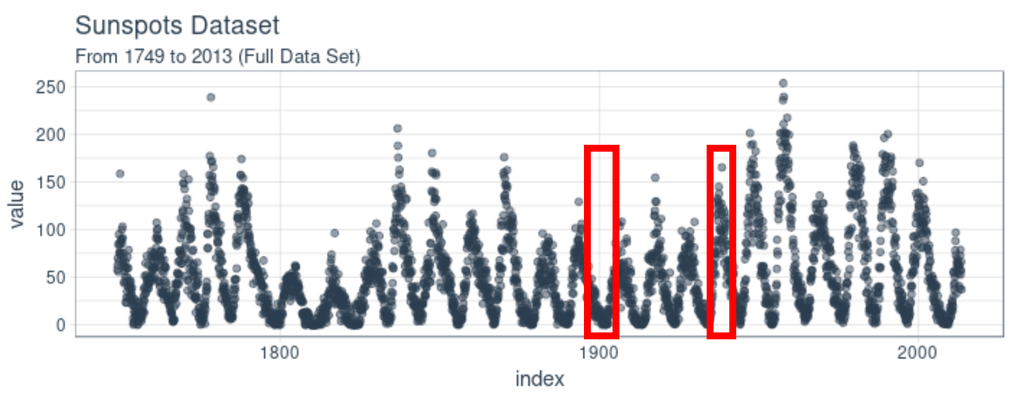

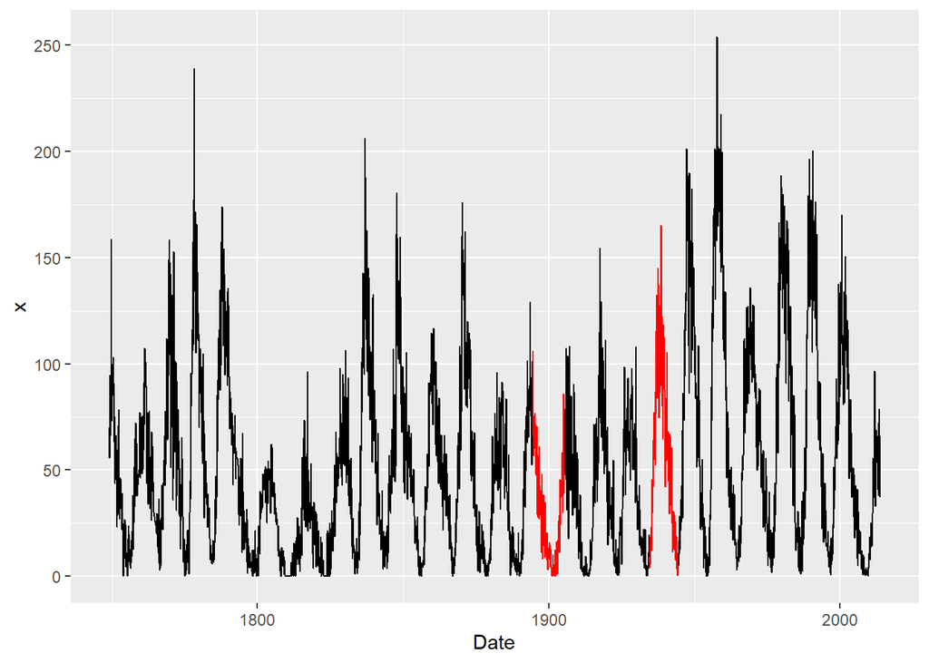

```r
# convert to data frame for plotting
sunspot = data.frame(as.data.frame(as.Date(as.yearmon(time(sunspot.month)))), sunspot.month)
names(sunspot) = c('Date', 'x')

# create first subset
sunspot1 = subset(sunspot, Date > as.Date('1894-05-01') & Date < as.Date('1905-07-01'))

# create second subset
sunspot2 = subset(sunspot, Date > as.Date('1934-05-01') & Date < as.Date('1944-07-01'))

# plot data w/ new subsets
ggplot(sunspot, aes(x = Date, y = x)) +
  geom_line() +
  scale_x_date(date_labels = '%Y') +
  geom_line(data = sunspot1, color = 'red') +
  geom_line(data = sunspot2, color = 'red')
```

It appears the subsets of the data are from June 1894 - June 1905 for the dip and June 1934 - June 1944. In order to determine if they satisfy condition three of stationarity, we need to look at their ACF.

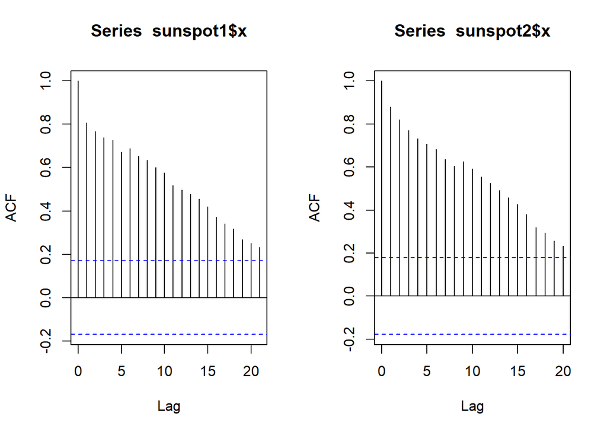

```r
# create plotting vector
par(mfrow=c(1,2))

# acf for first subset
acf(sunspot1$x)

# acf for second subset
acf(sunspot2$x)
```

Based on the ACF, it appears the autocorrelation dampens as the lag increases. This is the case for both subsets! This is an indication that the values are dependent on how far they are in time, not when they are in time. As a result, this would indicate that condition three has been met.